# Demand Side III: Public Opinion and the Information Environment

POLISCI 158 · AI & Politics · Session 6 · Mon, Oct 12, 2026

Simone Paci

## Roadmap

1. Part I: Public opinion
   - Explain where opinions about AI come from: preferences, attitudes, beliefs, interests and values
   - Read a survey trend or model result and name one limit
2. Part II: Events, influence and deliberation
   - Read a study’s finding and name what it does and does not measure
   - Evaluate how AI changes the channels that shape opinion and deliberation: promise and risk

## Do you trust AI more or less than *most people* do?

- Hands up, or write it down

# Part I: Public opinion

## What do Americans think about AI now?

[figure not shown]

Pew · more concerned than excited

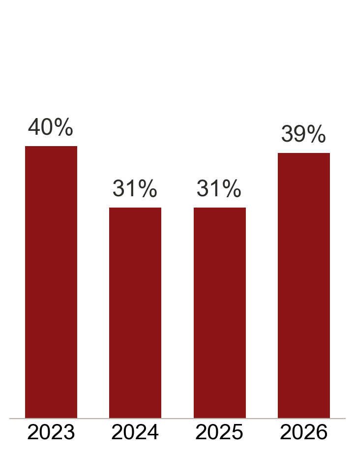

Gallup · more harm than good

Pew Research Center, [Americans have grown more concerned about AI over time](https://www.pewresearch.org/chart/americans-have-grown-more-concerned-about-ai-over-time/). U.S. adults, June 22–28, 2026.  
Bentley-Gallup, [Americans Cool Toward AI](https://news.gallup.com/poll/712751/americans-cool-toward.aspx), Jul 28, 2026. Gallup Panel, May 2023–May 2026.  
Different questions; not one series.

## Do experts and the public see AI the same way?

[figure not shown]

Pew Research Center, [How the U.S. Public and AI Experts View Artificial Intelligence](https://www.pewresearch.org/internet/2025/04/03/how-the-us-public-and-ai-experts-view-artificial-intelligence/), Apr 3, 2025. Public: Aug 12–18, 2024. Experts: Aug 14–Oct 31, 2024.

## Who trusts their government to regulate AI?

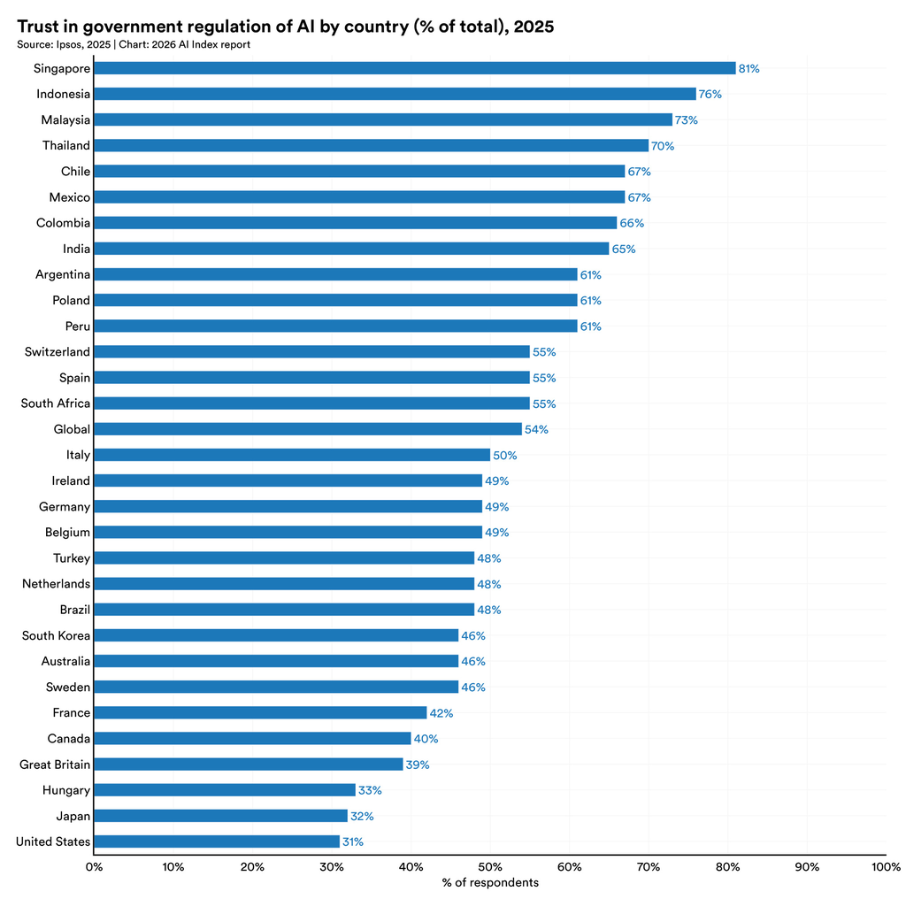

Stanford HAI, [AI Index 2026](https://hai.stanford.edu/ai-index/2026-ai-index-report/public-opinion), Fig. 9.3.1. Data: Ipsos, 2025.

## Is AI becoming partisan? Start with who uses it at work

Workers who use AI at work frequently, Q1 2026

- Democrats 30.1% · Republicans 25%

Measures use at work, not opinion

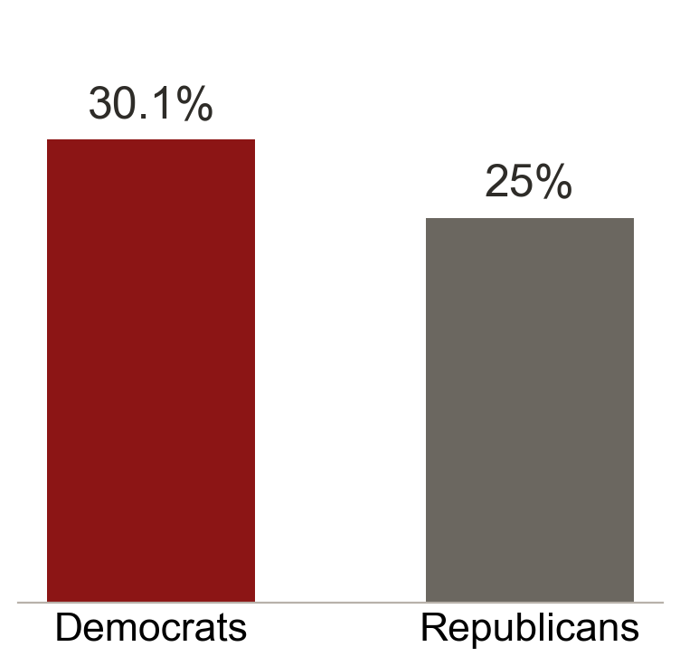

Bloom & Makridis, [NBER Working Paper w34813](https://www.nber.org/papers/w34813), 2026. Gallup Panel workers, ages 25–65, 2024–2026.

## Things are changing?

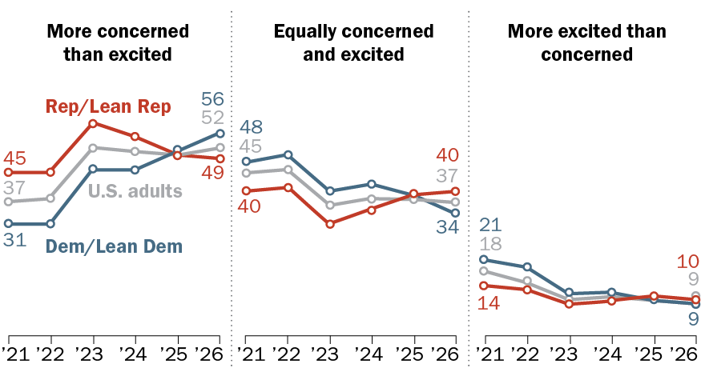

Pew Research Center, Anderson & Bishop, [Democrats are now more worried than Republicans about AI and its impact on jobs](https://www.pewresearch.org/short-reads/2026/09/16/democrats-are-now-more-worried-than-republicans-about-ai-and-its-impact-on-jobs/), Sep 16, 2026. U.S. adults, June 22–28, 2026. Party includes leaners.

## Where does public opinion come from?

**Preferences** → “what you want”

- policies, candidates

**Attitudes** → “how you feel”

- favorability, salience, values

**Beliefs** → “what you believe”

- expectations

## Why is measuring opinion so hard?

Rational ignorance

- No one can know everything

Stated vs. revealed preference

- Cheap talk vs. costly action

The menu of options

- Change the alternative, change the answer?

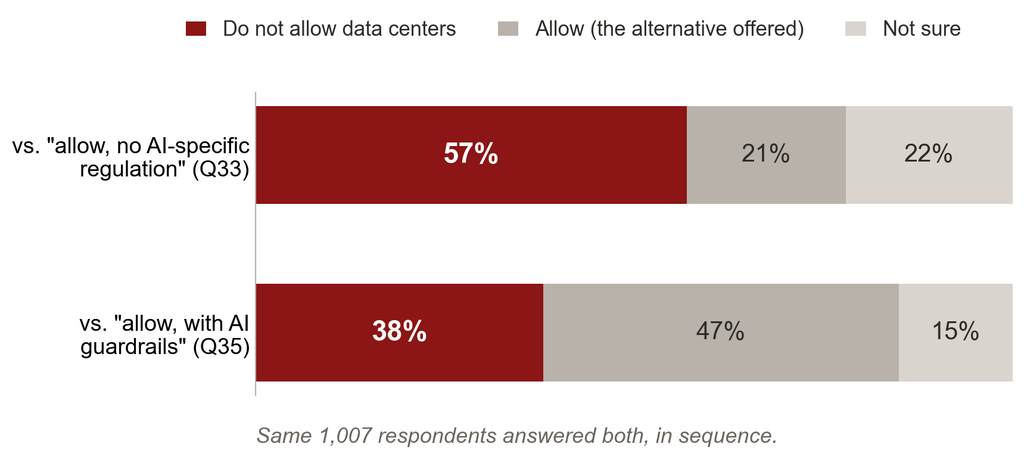

AI Policy Institute, [toplines](https://theaipi.org/wp-content/uploads/2026/06/Toplines-AIPI-June-10-11.pdf) and [crosstabs](https://theaipi.org/wp-content/uploads/2026/06/Crosstabs-AIPI-June-10-11.pdf), June 10–11, 2026. 1,007 U.S. likely voters, online opt-in panels. Not a randomized split ballot.

## Does self-interest stop at your paycheck?

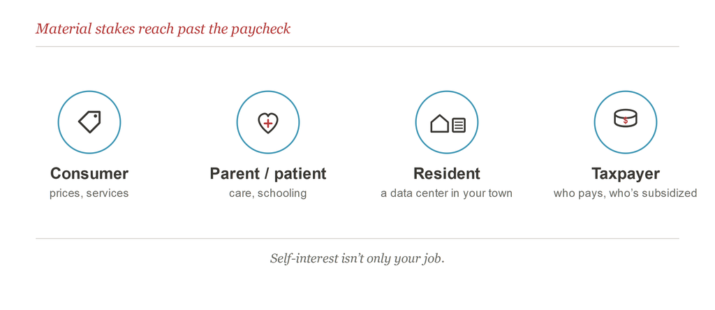

## Do values matter as much as interests?

Sociotropic, others-regarding

- = “happy if others are happy”

Moral, symbolic

- justice, tradition, status = “happy for something to be right”

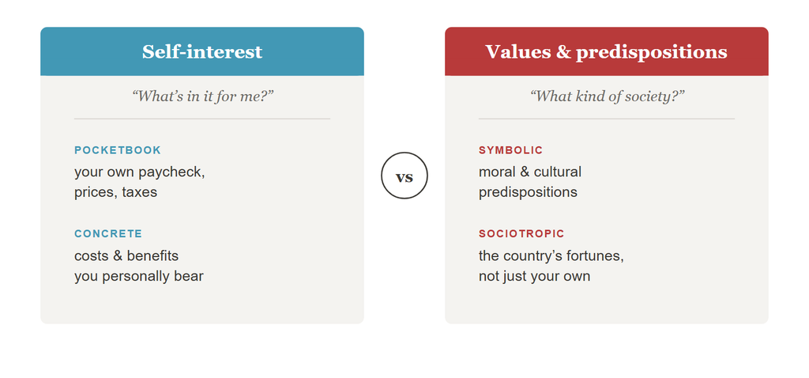

## What do you think others think?

First-order = “what I think”

Second-order = “what I think others think”

- social desirability · bandwagon effects · pluralistic ignorance

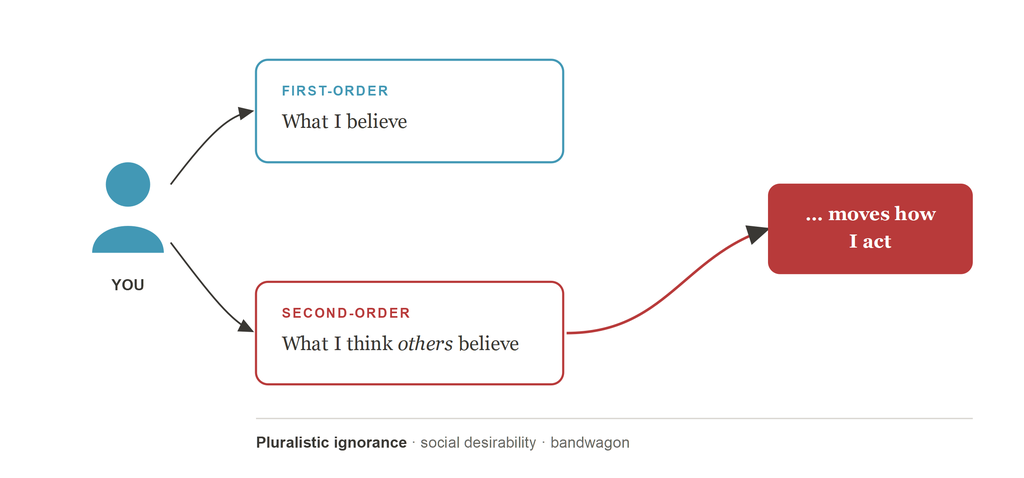

## AI is new. Where do our beliefs come from: fiction?

[figure not shown]

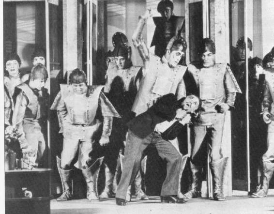

[figure not shown]

[Frankenstein (1931) poster](https://commons.wikimedia.org/wiki/File:Frankenstein_poster_1931.jpg); [R.U.R., Theatre Guild production, 1928–29](https://commons.wikimedia.org/wiki/File:Capek_RUR.jpg); [Metropolis (1926), set photograph by Horst von Harbou](https://commons.wikimedia.org/wiki/File:Horst_von_Harbou_-_Metropolis_Maschinenmensch.jpg). All via Wikimedia Commons.

## Lessons from the last tech revolution?

[figure not shown]

Jonathan Haidt, [*The Anxious Generation*](https://www.penguinrandomhouse.com/books/729231/the-anxious-generation-by-jonathan-haidt/), Penguin Press, 2024. Cover shown for commentary.

## Activity: what predicts AI favorability?

PPIC Statewide Survey, Nov 2024 · 2,344 California adults

Outcome: Q46 · “Do you have a favorable or unfavorable opinion of AI or artificial intelligence?”

Predictors in the model

- Exposure: heard about AI
- Economic circumstances: income, employment, bills, health care, housing, expectations for your kids
- Values and politics: ideology, registered party, views on the governor, workers, inequality, the country
- Demographics: age, gender, education, race

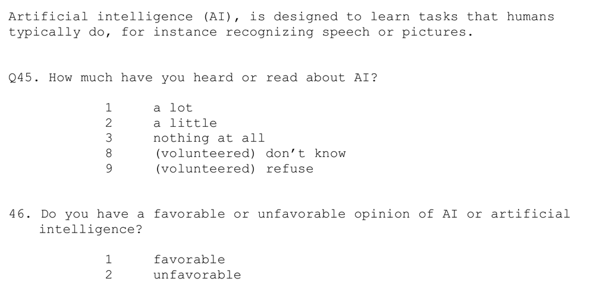

Source: PPIC Statewide Survey; Mark Baldassare, Survey Director. PPIC bears no responsibility for interpretations or conclusions.

## Pick a variable. Which way does it point?

1. Alone (2 min): pick one variable from the list
2. Pairs (4 min): predict its direction; write one reason
3. Compare with your neighbor’s prediction

Written answers welcome

## Reveal: what predicts favorability?

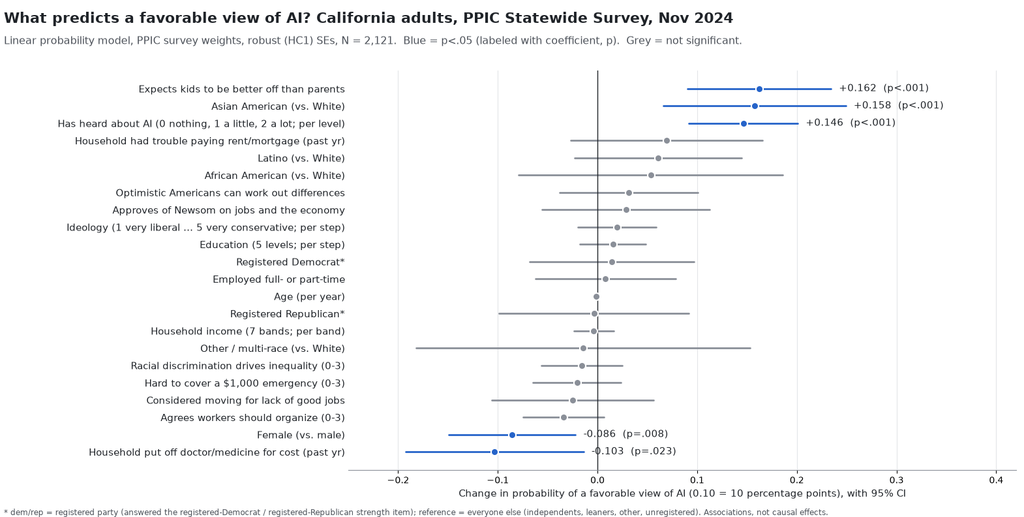

Associations, not causes

PPIC Statewide Survey, Nov 2024; Mark Baldassare, Survey Director. PPIC bears no responsibility for interpretations or conclusions. Analysis: instructor’s weighted linear probability model, N = 2,121.

## What would make this result misleading?

Confound

- Is something else driving both?

Wording

- What did respondents read first?

Sample

- Who is, and isn’t, in the data?

## Do elites tell us what to think about AI?

Elite cues → mass opinion

“…a minimally burdensome national standard — not 50 discordant State ones.”

- Executive Order 14365, Dec 11, 2025

“We need a federal moratorium on AI data centers.”

- Sen. Bernie Sanders, Mar 25, 2026

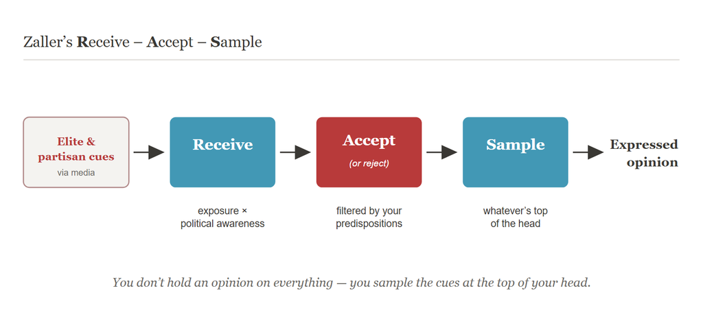

[White House, Executive Order 14365](https://www.whitehouse.gov/presidential-actions/2025/12/eliminating-state-law-obstruction-of-national-artificial-intelligence-policy/), “Ensuring a National Policy Framework for Artificial Intelligence,” Dec 11, 2025; [Sen. Sanders, press release](https://www.sanders.senate.gov/press-releases/news-sanders-ocasio-cortez-announce-ai-data-center-moratorium-act/), Mar 25, 2026.

## Which AI story gets told, and how?

Agenda setting = which issues matter?

Framing = which side of the issue matters?

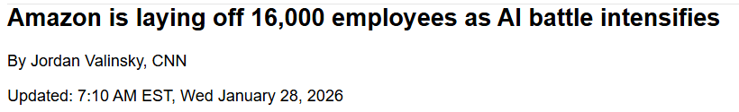

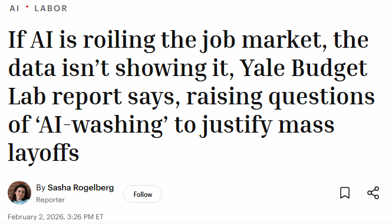

[CNN](https://www.cnn.com/2026/01/28/tech/amazon-layoffs-ai), Jordan Valinsky, Jan 28, 2026 (CNN Lite edition shown); [Fortune](https://fortune.com/2026/02/02/ai-labor-market-yale-budget-lab-ai-washing/), Sasha Rogelberg, Feb 2, 2026.

# Part II: Events, influence and deliberation

## Do AI-caused harms raise demand for regulation?

When AI causes harm, do people want more rules?

- Harm → concern → demand for regulation?
- Which harms, and for whom?

## Do alarming headlines raise concern, or demand for rules?

Three preregistered experiments, N = 10,800

- Treatment: headlines about existential AI risk
- Concern rose
- Support for AI policy did not move (Study 2)

Headline

↗

Concern ✓

↘

Policy support ✗

Hoes & Gilardi, “Existential risk narratives about AI do not distract from its immediate harms,” *PNAS* 122 (16), e2419055122, 2025. [doi:10.1073/pnas.2419055122](https://doi.org/10.1073/pnas.2419055122).

## Does feeling exposed raise support for regulation?

UK panel: the same people, over time

- More AI exposure or perceived job risk → more support for stronger regulation
- Optimism does not offset it
- Observational, not experimental

Exposure / perceived job risk → Regulation support

Grant, Green & Evans, “New tech, new threat? Occupational exposure to artificial intelligence increases support for AI regulation,” *Journal of European Public Policy*, online Aug 4, 2026. [doi:10.1080/13501763.2026.2710714](https://doi.org/10.1080/13501763.2026.2710714).

## What we still don’t know

Headline → concern ✓ · policy support ✗ (experiment)

Job exposure → regulation support ✓ (panel)

A real incident → regulation support?

- We have not found a published experiment that tests this

## Who is really speaking? Alleged AI astroturfing

Civil society = the space between the state and markets

South Coast AQMD, June 2025

- 20,000+ comments opposing clean-air rules, reportedly generated by one firm, CiviClick
- Board rejected the rules 7–5
- AI use alleged; the company denies it

[figure not shown]

Hayley Smith, *Los Angeles Times*, Feb 17, 2026; [GovTech reprint](https://www.govtech.com/artificial-intelligence/ai-generated-comments-swayed-california-air-decision), Feb 24, 2026. Company response: *Los Angeles Times*, Aug 28, 2026.

## What is deliberative democracy?

Representation vs. deliberation

Public debate as a central tenet of democracy

- Legitimacy = reasoning > votes

[figure not shown]

America in One Room logo © Stanford University, [Deliberative Democracy Lab](https://deliberation.stanford.edu/america-in-one-room).

## Can AI help deliberation?

The Habermas Machine

- AI drafts group statements from participants’ views
- Preferred 56% of the time vs. 44% for human mediators
- “Mediators” = randomly assigned participants, not professionals

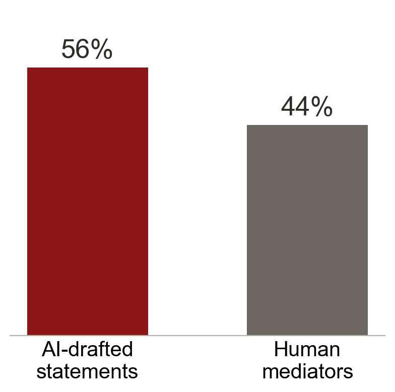

Tessler et al., “AI can help humans find common ground in democratic deliberation,” [*Science* 386 (6719), eadq2852](https://doi.org/10.1126/science.adq2852), Oct 18, 2024.

## Could AI hurt deliberation?

Technological solutionism = “societal problems can be ‘solved’ through technology”

- For deliberation: technology as an “efficient” fix for the “problems” of minipublics
- Case: the Habermas Machine

[figure not shown]

Oleart & Palomo Hernández, “Why AI Technosolutionism Harms Democracy and Deliberation: The EU, Citizens’ Assemblies and the Habermas Machine,” [*Journal of Deliberative Democracy* 21 (1): 1–6](https://doi.org/10.16997/jdd.1839), 2025. CC BY 4.0.

## Debate: does AI-assisted deliberation strengthen or weaken legitimacy?

Pairs, assigned sides

- Side A: it strengthens legitimacy
- Side B: it weakens legitimacy

2 minutes to build your best case · write or speak

## Put it together: from beliefs to pressure to deliberation

**Beliefs**

Where do views come from?

→

**Pressure**

How do they reach government?

→

**Deliberation**

Can AI change how we decide together?

Exit card (optional): one testable hypothesis to sharpen your project

## See you next class

# Backup slides

## Can litigation change AI rules?

Strategic litigation

- Bartz v. Anthropic · final approval of a $1.5 billion class settlement, Jul 20, 2026
- Authors Guild v. OpenAI · no ruling yet

[Authors Guild, Jul 21, 2026](https://authorsguild.org/news/court-grants-final-approval-anthropic-copyright-settlement/); [Authors Guild, Sep 21, 2026](https://authorsguild.org/news/ag-v-openai-top-execs-knew-mass-book-piracy-was-illegal/).

## Does AI search divert traffic from knowledge institutions?

[figure not shown]

Pew Research Center, [Chapekis & Lieb](https://www.pewresearch.org/short-reads/2025/07/22/google-users-are-less-likely-to-click-on-links-when-an-ai-summary-appears-in-the-results/), Jul 22, 2025. 68,879 searches by 900 adults, March 2025.